# Week 4 Quiz

## Question 1

What is produced at the end of this snippet of R code?

```r
set.seed(1)
rpois(5, 2)
```

```
## [1] 1 1 2 4 1
```

Solution: A vector with the numbers 1, 1, 2, 4, 1

## Question 2

What R function can be used to generate standard Normal random variables?  
Solution:rnorm

## Question 3

When simulating data, why is using the set.seed() function important?  
Solution:It ensures that the sequence of random numbers starts in a specific place and is therefore reproducible

## Question 4

Which function can be used to evaluate the inverse cumulative distribution function for the Poisson distribution?  
Solution:qpois

## Question 5

What does the following code do?

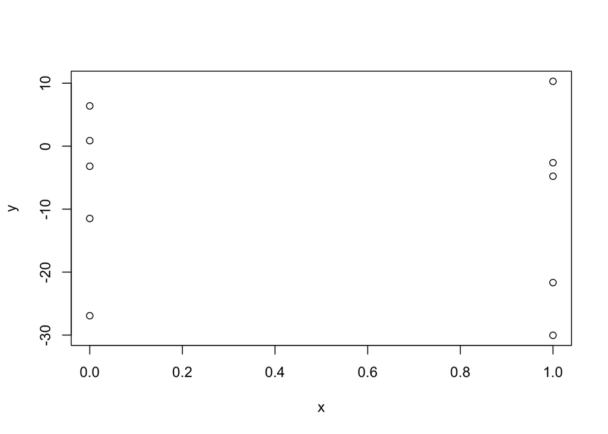

```r
set.seed(10)
x <- rep(0:1, each = 5)
e <- rnorm(10, 0, 20)
y <- 0.5 + 2 * x + e
plot(x,y)
```

Solution:Generate data from a Normal linear model

## Question 6

What R function can be used to generate Binomial random variables?  
Solution:rbinom

## Question 7

What aspect of the R runtime does the profiler keep track of when an R expression is evaluated?  
Solution:the function call stack

## Question 9

When using ‘system.time()’, what is the user time?  
Solution:It is the time spent by the CPU evaluating an expression

## Question 10

If a computer has more than one available processor and R is able to take advantage of that, then which of the following is true when using ‘system.time()’?  
Solution:elapsed time may be smaller than user time